# Where Are the Fishes

Bilsay Varcin

April 3, 2020

## Backscatter - remote sensing in the ocean

[figure not shown]

Reflections. No, I’m not talking about contemplating your existence within the Tidyverse or understanding what that spline did to your data. I’m talking about echoes. Specifically, acoustic echoes called “backscatter.” Marine scientists use acoustic backscatter to understand the distribution of organisms in the ocean.

In this analysis, we are going to wrangle active acoustic data and plot the mean volume backscatter associated with fish with swim-bladders in relation to bathymetry (depth of the seafloor).

These acoustic data were collected from a research vessel that crossed the shelf break in the Mid-Atlantic Bight (NOAA cruise HB1103) and were preprocessed using the software, Echoview.

## What is the “shelf break”?

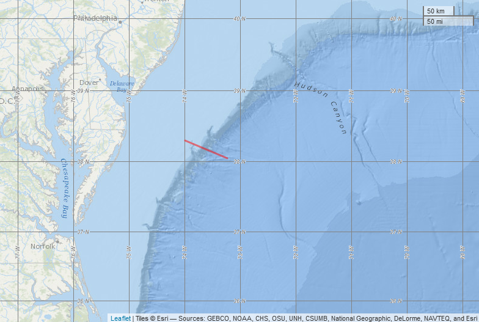

The red line in the map to the left is the ship’s track across the shelf break in the Mid-Atlantic Bight. But what is the “shelf break”? It’s the underwater version of a cliff.

In most marine ecosystems, the shelf break is also a highly dynamic and productive area that provides food and habitat for many species. From the smallest phytoplankton to the largest marine mammals, sharks, seabirds, tunas, and sea turtles - they all use this area at some point in their life cycles. And, we’re going to play with some active acoustic data from this fantastic region!

But first, let’s clean up the bathymetry (depth) data and get it ready for plotting.

## Where ever you go, there you are

Now that we have removed the bad data points and calculated the cumulative distance the ship traveled, let’s plot the data.

A horizontal view of the ship’s track will show us if the ship deviated from the track line or if there were any breaks in the data.

A plot of the depth of the seafloor along the track line will show us the position of the shelf break. In a spatial analysis of the track line data, we would typically work in the packages sp and sf, but that’s a topic all its own. For now, we’ll create a couple of track line plots with the latitude, longitude, depth, and distance along the track line.

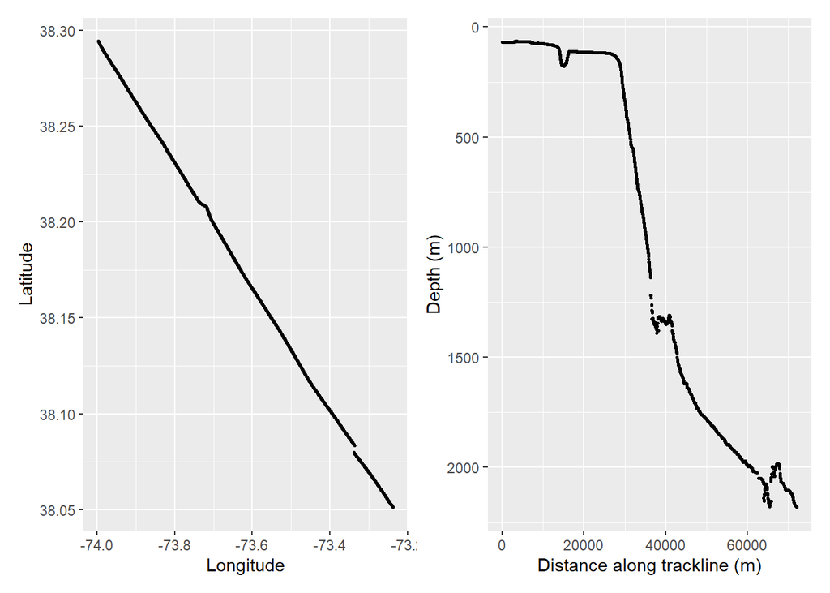

## Here fishy, fishy, fishy…

Volume backscatter (Sv) is a measure of the relative density of organisms. In this case, because we preprocessed the data in Echoview to look for fish-like scattering, our final plot of the volume backscatter data, Sv_mean, will give us an indication of the distribution of fish along the track line.

Will there be sections of the track line with higher/lower densities if fish? Let’s find out!

```
## Observations: 724
## Variables: 78
## $ Process_ID                           <dbl> 20216, 20216, 20216, 20216, 20...
## $ Interval                             <dbl> 4, 5, 6, 7, 8, 9, 10, 11, 12, ...
## $ Layer                                <dbl> 1, 1, 1, 1, 1, 1, 1, 1, 1, 1, ...
## $ Sv_mean                              <dbl> -67.97805, -67.65053, -66.6586...
## $ NASC                                 <dbl> 365.6001, 429.4046, 539.5769, ...
## $ Sv_max                               <dbl> -53.93325, -54.51390, -51.3186...
## $ Sv_min                               <dbl> -88.67275, -87.36100, -88.9946...
## $ Sv_noise                             <dbl> -967.8684, -967.6432, -967.623...
## $ NASC_noise                           <dbl> 0, 0, 0, 0, 0, 0, 0, 0, 0, 0, ...
## $ Height_mean                          <dbl> 53.25000, 58.00000, 58.00000, ...
## $ Depth_mean                           <dbl> 39.04617, 39.00000, 39.00000, ...
## $ Good_samples                         <dbl> 639, 522, 464, 464, 406, 464, ...
## $ Layer_depth_min                      <dbl> 0, 0, 0, 0, 0, 0, 0, 0, 0, 0, ...
```

[output cut: 65 more lines]

## That’s a lot of variables!

Wow! 724 observations of 78 variables! This is the full data export from Echoview, but remember, we’re only interested in the volume backscatter data, Sv_mean, and the few other variables needed to plot the data.

These backscatter data were integrated into grid cells that are 200 meters along the ship’s path (numbered in the variable, Interval), by 250 meters deep, (numbered in the variable, Layer), making a coordinate system referenced to the ship’s path and depth. We are going to explore the first depth layer.